# Brownlows Bets

Brooke De La Torre

Year 2020

# 1 Introduction

We will be showing the profit that Brownlow made from the bet he made with students regarding whether at least 2 people had birthdays on the same date.

# 2 Methods

we will solve this problem by resampling. we will set up days of the year, take a random sample of 35, and see if two or more have the same birthday.

```r
daysYEAR=1:365
bDAYS=sample(daysYEAR,35,replace=TRUE)
length(unique(bDAYS))
```

```
## [1] 33
```

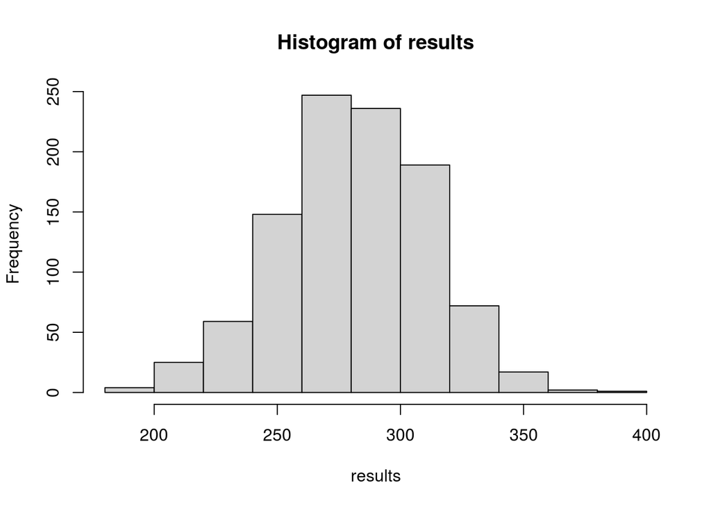

```r
results=vector("numeric")
for(j in 1:1000){
bank=0
for(i in 1:637){
  class = sample(daysYEAR,35,replace=TRUE)
  n=length(unique(class))
  if(n == 35)bank=bank-2
  else bank=bank+1
}
results[j]=bank
}
hist(results)
```

# 3 Profit Estimate

```r
favstats(results)
```

```
##  min  Q1 median  Q3 max    mean       sd    n missing
##  184 262    283 301 388 281.731 30.10583 1000       0
```

```r
results=vector("numeric")
for(j in 1:1000){
bank=0
for(i in 1:637){
  class = sample(daysYEAR,35,replace=TRUE)
  n=length(unique(class))
  if(n == 35)bank=bank-2
  else bank=bank+1
}
results[j]=bank
}
sortRESULTS=sort(results)
lcl=sortRESULTS[25]
ucl=sortRESULTS[975]
```

lower confidence limit= 220 upper confidence limit= 337